# EasyVisa Project

## Context:

Business communities in the United States are facing high demand for human resources, but one of the constant challenges is identifying and attracting the right talent, which is perhaps the most important element in remaining competitive. Companies in the United States look for hard-working, talented, and qualified individuals both locally as well as abroad.

The Immigration and Nationality Act (INA) of the US permits foreign workers to come to the United States to work on either a temporary or permanent basis. The act also protects US workers against adverse impacts on their wages or working conditions by ensuring US employers' compliance with statutory requirements when they hire foreign workers to fill workforce shortages. The immigration programs are administered by the Office of Foreign Labor Certification (OFLC).

OFLC processes job certification applications for employers seeking to bring foreign workers into the United States and grants certifications in those cases where employers can demonstrate that there are not sufficient US workers available to perform the work at wages that meet or exceed the wage paid for the occupation in the area of intended employment.

## Objective:

In FY 2016, the OFLC processed 775,979 employer applications for 1,699,957 positions for temporary and permanent labor certifications. This was a nine percent increase in the overall number of processed applications from the previous year. The process of reviewing every case is becoming a tedious task as the number of applicants is increasing every year.

The increasing number of applicants every year calls for a Machine Learning based solution that can help in shortlisting the candidates having higher chances of VISA approval. OFLC has hired your firm EasyVisa for data-driven solutions. You as a data scientist have to analyze the data provided and, with the help of a classification model:

- Facilitate the process of visa approvals.
- Recommend a suitable profile for the applicants for whom the visa should be certified or denied based on the drivers that significantly influence the case status.

## Data Description

The data contains the different attributes of the employee and the employer. The detailed data dictionary is given below.

- **case_id**: ID of each visa application
- **continent**: Information for the employee's continent of residence
- **education_of_employee**: Information of education of the employee
- **has_job_experience**: Does the employee have any job experience? Y= Yes; N = No
- **requires_job_training**: Does the employee require any job training? Y = Yes; N = No
- **no_of_employees**: Number of employees in the employer's company
- **yr_of_estab**: Year in which the employer's company was established
- **region_of_employment**: Information of foreign worker's intended region of employment in the US.
- **prevailing_wage**: Average wage paid to similarly employed workers in a specific occupation in the area of intended employment. The purpose of the prevailing wage is to ensure that the foreign worker is not underpaid compared to other workers offering the same or similar service in the same area of employment.
- **unit_of_wage**: Unit of prevailing wage. Values include Hourly, Weekly, Monthly, and Yearly.
- **full_time_position**: Is the position of work full-time? Y = Full Time Position; N = Part Time Position
- **case_status**: Flag indicating if the Visa was certified or denied

## Importing necessary libraries and data

```python
# Installing the libraries with the specified version - run once
#!pip install numpy==1.25.2 pandas==1.5.3 scikit-learn==1.2.2 matplotlib==3.7.1 seaborn==0.13.1 xgboost==2.0.3
```

```python
# Import the libraries we commonly use
# To ignore warnings
import warnings
warnings.filterwarnings('ignore')

# Libraries to help with reading and manipulating data
import numpy as np
import pandas as pd

# Library to split data
from sklearn.model_selection import train_test_split

# Libraries to help with data visualization
import matplotlib.pyplot as plt
import seaborn as sns

# Removes the limit for the number of displayed columns
pd.set_option("display.max_columns", None)
# Sets the limit for the number of displayed rows
pd.set_option("display.max_rows", 100)
```

**Note**: *After running the above cell, kindly restart the notebook kernel and run all cells sequentially from the start again.*

```python
# Load Google Colab
from google.colab import drive
drive.mount('/content/drive')
```

```python
# Define path to data file
path = r'/content/drive/MyDrive/Learning/Data Coursework/PGP-DSBA/5-Ensemble Techniques/Project 5/'
df = pd.read_csv(path + 'EasyVisa.csv')
```

## Data Overview

- Observations
- Sanity checks

```python
# Check the shape of the data
df.shape
print('The data set has', df.shape[0], 'rows', 'and', df.shape[1], 'columns')
```

```
The data set has 25480 rows and 12 columns
```

```python
# Check the dataset details
df.info()
```

```
<class 'pandas.core.frame.DataFrame'>
RangeIndex: 25480 entries, 0 to 25479
Data columns (total 12 columns):
 #   Column                 Non-Null Count  Dtype
---  ------                 --------------  -----
 0   case_id                25480 non-null  object
 1   continent              25480 non-null  object
 2   education_of_employee  25480 non-null  object
 3   has_job_experience     25480 non-null  object
 4   requires_job_training  25480 non-null  object
 5   no_of_employees        25480 non-null  int64
 6   yr_of_estab            25480 non-null  int64
 7   region_of_employment   25480 non-null  object
 8   prevailing_wage        25480 non-null  float64
 9   unit_of_wage           25480 non-null  object
 10  full_time_position     25480 non-null  object
 11  case_status            25480 non-null  object
dtypes: float64(1), int64(2), object(9)
memory usage: 2.3+ MB
```

```python
# Iterate through each column and determine its data type

# Calculate number of rows and columns
num_rows, num_cols = df.shape

# Initialize dictionary to store counts of each data type
data_type_counts = {}

# Iterate through each column and determine its data type
for col in df.columns:
    data_type = str(df[col].dtype)
    if data_type in data_type_counts:
        data_type_counts[data_type] += 1
    else:
        data_type_counts[data_type] = 1

# Print summary information
print(f'The data has {num_rows} rows and {num_cols} columns total:')
print()
for dtype, count in data_type_counts.items():
    print(f'{count} columns of type {dtype}')
```

```
The data has 25480 rows and 12 columns total:

9 columns of type object
2 columns of type int64
1 columns of type float64
```

```python
# Check for null values
df.isnull()

# No nulls exist in this dataset.
```

|  | case_id | continent | education_of_employee | has_job_experience | requires_job_training | no_of_employees | yr_of_estab | region_of_employment | prevailing_wage | unit_of_wage | full_time_position | case_status |
| --- | --- | --- | --- | --- | --- | --- | --- | --- | --- | --- | --- | --- |
| 0 | False | False | False | False | False | False | False | False | False | False | False | False |
| 1 | False | False | False | False | False | False | False | False | False | False | False | False |
| 2 | False | False | False | False | False | False | False | False | False | False | False | False |
| 3 | False | False | False | False | False | False | False | False | False | False | False | False |
| 4 | False | False | False | False | False | False | False | False | False | False | False | False |
| ... | ... | ... | ... | ... | ... | ... | ... | ... | ... | ... | ... | ... |
| 25475 | False | False | False | False | False | False | False | False | False | False | False | False |
| 25476 | False | False | False | False | False | False | False | False | False | False | False | False |
| 25477 | False | False | False | False | False | False | False | False | False | False | False | False |
| 25478 | False | False | False | False | False | False | False | False | False | False | False | False |
| 25479 | False | False | False | False | False | False | False | False | False | False | False | False |

25480 rows × 12 columns

```python
# Check for duplicate values
df.duplicated().sum()

# No duplicates exist in this dataset.
```

```
0
```

```python
# Retrieve and preview the categorial column values, using a list.
# Create numerical and categorical column lists
list_catcol = df.select_dtypes(include=['object']).columns.to_list()
list_numcol = df.select_dtypes(exclude=['object']).columns.to_list()

# Use a for loop to show the counts and percent contribution of each categorical column.
for col in list_catcol:
  print(f'***** {col} *****')
  print('Preview counts for:',df[col].value_counts(),'\n')
  print('Preview % breakdown for:',df[col].value_counts(normalize=True),'\n')
```

```
***** case_id *****
Preview counts for: case_id
EZYV01       1
EZYV16995    1
EZYV16993    1
EZYV16992    1
EZYV16991    1
            ..
EZYV8492     1
EZYV8491     1
EZYV8490     1
EZYV8489     1
EZYV25480    1
Name: count, Length: 25480, dtype: int64

Preview % breakdown for: case_id
EZYV01       0.000039
EZYV16995    0.000039
EZYV16993    0.000039
EZYV16992    0.000039
EZYV16991    0.000039
               ...
EZYV8492     0.000039
EZYV8491     0.000039
EZYV8490     0.000039
EZYV8489     0.000039
EZYV25480    0.000039
Name: proportion, Length: 25480, dtype: float64

***** continent *****
Preview counts for: continent
Asia             16861
Europe            3732
North America     3292
South America      852
Africa             551
Oceania            192
Name: count, dtype: int64

Preview % breakdown for: continent
```

[output cut: 83 more lines]

```
Preview % breakdown for: full_time_position
Y    0.89376
N    0.10624
Name: proportion, dtype: float64

***** case_status *****
Preview counts for: case_status
Certified    17018
Denied        8462
Name: count, dtype: int64

Preview % breakdown for: case_status
Certified    0.667896
Denied       0.332104
Name: proportion, dtype: float64
```

```python
# Check counts, unique counts and duplicate values for each column. Based on this, we can decide how to approach each variable.

# Create a dictionary to store series unique values for categorical variables
series_values = {}

# Since we have some numerical values that are not continuous data, we need to inspect each column
for col in df.columns:
    # Calculate the number of duplicate values
    duplicate_count = df[col].count() - df[col].nunique()

    print('Series', col, 'has', df[col].nunique(), 'unique values and', duplicate_count, 'duplicates.' )

    # Let's store a series in the dictionary for any column with less than 25 unique values - for this particular dataset 25 will work)
    if df[col].nunique() < 25:
        # Store unique values in dictionary with column name as key
        series_values[col] = list(df[col].unique())
        print('    Unique values for', col, ':', series_values[col])
```

```
Series case_id has 25480 unique values and 0 duplicates.
Series continent has 6 unique values and 25474 duplicates.
    Unique values for continent : ['Asia', 'Africa', 'North America', 'Europe', 'South America', 'Oceania']
Series education_of_employee has 4 unique values and 25476 duplicates.
    Unique values for education_of_employee : ['High School', "Master's", "Bachelor's", 'Doctorate']
Series has_job_experience has 2 unique values and 25478 duplicates.
    Unique values for has_job_experience : ['N', 'Y']
Series requires_job_training has 2 unique values and 25478 duplicates.
    Unique values for requires_job_training : ['N', 'Y']
Series no_of_employees has 7105 unique values and 18375 duplicates.
Series yr_of_estab has 199 unique values and 25281 duplicates.
Series region_of_employment has 5 unique values and 25475 duplicates.
    Unique values for region_of_employment : ['West', 'Northeast', 'South', 'Midwest', 'Island']
Series prevailing_wage has 25454 unique values and 26 duplicates.
Series unit_of_wage has 4 unique values and 25476 duplicates.
    Unique values for unit_of_wage : ['Hour', 'Year', 'Week', 'Month']
Series full_time_position has 2 unique values and 25478 duplicates.
    Unique values for full_time_position : ['Y', 'N']
Series case_status has 2 unique values and 25478 duplicates.
    Unique values for case_status : ['Denied', 'Certified']
```

```python
# Preview the data characteristics for numerical columns
df.describe().T
```

|  | count | mean | std | min | 25% | 50% | 75% | max |
| --- | --- | --- | --- | --- | --- | --- | --- | --- |
| no_of_employees | 25480.0 | 5667.043210 | 22877.928848 | -26.0000 | 1022.00 | 2109.00 | 3504.0000 | 602069.00 |
| yr_of_estab | 25480.0 | 1979.409929 | 42.366929 | 1800.0000 | 1976.00 | 1997.00 | 2005.0000 | 2016.00 |
| prevailing_wage | 25480.0 | 74455.814592 | 52815.942327 | 2.1367 | 34015.48 | 70308.21 | 107735.5125 | 319210.27 |

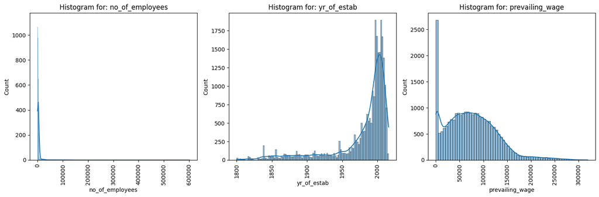

```python
# Preview the histograms here quickly for data insights into continuous data

# Create numerical and categorical column lists
list_catcol = df.select_dtypes(include=['object']).columns.to_list()
list_numcol = df.select_dtypes(exclude=['object']).columns.to_list()


plt.figure(figsize=(15, 5))  # Adjust the figure size as needed

for i, col in enumerate(list_numcol, start=1):
    plt.subplot(1, len(list_numcol), i)
    title1 = f'Histogram for: {col}'
    sns.histplot(data=df, x=col, kde=True)
    plt.tight_layout()
    plt.xticks(rotation=90)
    plt.title(title1)

plt.show()
```

```python
# Preview the data
df
```

|  | case_id | continent | education_of_employee | has_job_experience | requires_job_training | no_of_employees | yr_of_estab | region_of_employment | prevailing_wage | unit_of_wage | full_time_position | case_status |
| --- | --- | --- | --- | --- | --- | --- | --- | --- | --- | --- | --- | --- |
| 0 | EZYV01 | Asia | High School | N | N | 14513 | 2007 | West | 592.2029 | Hour | Y | Denied |
| 1 | EZYV02 | Asia | Master's | Y | N | 2412 | 2002 | Northeast | 83425.6500 | Year | Y | Certified |
| 2 | EZYV03 | Asia | Bachelor's | N | Y | 44444 | 2008 | West | 122996.8600 | Year | Y | Denied |
| 3 | EZYV04 | Asia | Bachelor's | N | N | 98 | 1897 | West | 83434.0300 | Year | Y | Denied |
| 4 | EZYV05 | Africa | Master's | Y | N | 1082 | 2005 | South | 149907.3900 | Year | Y | Certified |
| ... | ... | ... | ... | ... | ... | ... | ... | ... | ... | ... | ... | ... |
| 25475 | EZYV25476 | Asia | Bachelor's | Y | Y | 2601 | 2008 | South | 77092.5700 | Year | Y | Certified |
| 25476 | EZYV25477 | Asia | High School | Y | N | 3274 | 2006 | Northeast | 279174.7900 | Year | Y | Certified |
| 25477 | EZYV25478 | Asia | Master's | Y | N | 1121 | 1910 | South | 146298.8500 | Year | N | Certified |
| 25478 | EZYV25479 | Asia | Master's | Y | Y | 1918 | 1887 | West | 86154.7700 | Year | Y | Certified |
| 25479 | EZYV25480 | Asia | Bachelor's | Y | N | 3195 | 1960 | Midwest | 70876.9100 | Year | Y | Certified |

25480 rows × 12 columns

**OBSERVATIONS**

The data has 25480 rows and 12 columns (series) total with no nulls and no duplicated values.

- 9 columns of type object
- 2 columns of type int64
- 1 columns of type float64

No null values exist in the dataset/so we do not need to perform NaN or fillna.() activities.

- case_status: Denied/Certified
- full_time_position: Y/N
- requires_job_training: Y/N
- has_job_experience: Y/N

We have several series that will likely be treated as dummy variables:

- continent: Asia/Africa/North America/Europe/South America/Oceania
- education_of_employee: High School/Master's/"Bachelor's/Doctorate
- region_of_employment: West/Northeast/South/Midwest/Island
- unit_of_wage: Hour/Year/Week/Month

The series no_of_employees has a very wide range of -26 to 602,069. We may need to examine outliers in our EDA analysis. Similarly, *prevailing_wage* ranges from 2 to 319,210.

The data is highly skewed for our continuous series:

- no_of_employees (right skewed, likely due to excessive range of data)
- yr_of_estab (left skewed)
- prevailing_wage (right skewed, with an unusually high numer of low values, and some right-skewness

# Exploratory Data Analysis (EDA)

- EDA is an important part of any project involving data.
- It is important to investigate and understand the data better before building a model with it.
- A few questions have been mentioned below which will help you approach the analysis in the right manner and generate insights from the data.
- A thorough analysis of the data, in addition to the questions mentioned below, should be done.

### EDA Helper Functions

The following functions aid in our EDA analysis and support effective visualizations.

```python
# Function to get counts and percentages for categorical values

def get_value_counts(df, column_name):
    ''' Function to get value counts and percentages'''

    value_counts = df[column_name].value_counts()
    value_percentages = df[column_name].value_counts(normalize=True)

    return value_counts, value_percentages
```

```python
# Function to exclude outliers by including specific percentiles

def cap_values_by_percent(df, column_name, min, max):
    '''
    Cap a DataFrame column to only include values between the 25th and 75th percentiles.

    df: pandas DataFrame
    column_name: column to be capped
    '''

    # Calculate the 25th and 75th percentiles
    q_min = df[column_name].quantile(min)
    q_max = df[column_name].quantile(max)

    # Filter the DataFrame to only include values between the 25th and 75th percentiles
    capped_df = df[(df[column_name] >= q_min) & (df[column_name] <= q_max)]

    return capped_df
```

```python
# Function to plot a boxplot and a histogram along the same scale.

def print_histogram_boxplot(data, feature, figsize=(12, 8), kde=False, bins=None, showfliers=None):
    '''
    Boxplot and histogram combined

    data: dataframe
    feature: dataframe column
    figsize: size of figure
    kde: whether to show the density curve (default False)
    bins: number of bins for histogram (default None)
    '''

    # Create two subplots
    f, (ax_box, ax_hist) = plt.subplots(
        nrows=2,      # Number of rows of the subplot grid= 2
        sharex=True,  # x-axis will be the same for all subplots
        gridspec_kw={'height_ratios': (0.25, 0.75)},
        figsize=figsize,
    )

    # Create boxplot and add triangle at mean value
    if showfliers:
      sns.boxplot(data=data, x=feature, ax=ax_box, showmeans=True, color='blue', showfliers=showfliers)
    else:
      sns.boxplot(data=data, x=feature, ax=ax_box, showmeans=True, color='blue')

    # Create histogram
    if bins:
      if showfliers:
        sns.histplot(data=data, x=feature, kde=kde, ax=ax_hist, bins=bins, showfliers=showfliers)
      else:
        sns.histplot(data=data, x=feature, kde=kde, ax=ax_hist, bins=bins)
    else:
      if showfliers:
        sns.histplot(data=data, x=feature, kde=kde, ax=ax_hist, showfliers=showfliers)
      else:
        sns.histplot(data=data, x=feature, kde=kde, ax=ax_hist)

    # Add mean to the histogram
    ax_hist.axvline(data[feature].mean(), color='green', linestyle='--')
    # Add median to the histogram
    ax_hist.axvline(data[feature].median(), color='black', linestyle='-')
```

```python
# Function to print a histogram with several controllable options, including hue, size and title
def print_histogram(data, column, width, height, titleText, hue=None, bins=None, method='auto'):
  ''' Print a single, sorted histogram with title and labels and optional hue'''

  # set figure size and title
  plt.figure(figsize=(width, height))
  plt.title(titleText)
  plt.xticks(rotation=90)

  # dynamically set the hue if passed in
  if hue == None:
    sns.histplot(data=data,x=column, legend=False);
  else:
    sns.histplot(data=data,x=column, hue=column, legend=False);

  # dynamically set bins
  if bins is None:
      if method == 'auto':
        bins = 'auto'
      else:
        bins = method
```

```python
# Function to print boxplot with several controllable options, including size and title
def print_boxplot(data, column, width, height, titleText):
  """ Print a single boxplot with title and labels """

  # set figure size and title
  plt.figure(figsize=(width, height))
  plt.title(titleText)

  # define plot
  sns.boxplot(data=data,x=column, showmeans=True);
  plt.show()
```

```python
# Function to print boxplot with numerical values and categorical hue
def print_categorical_boxplot(data, x_column, y_column, width, height, titleText):
  """ Print a single boxplot with title and labels and hue """

  # set figure size and title
  plt.figure(figsize=(width, height))
  plt.title(titleText)

  # define plot
  sns.boxplot(data=data,x=x_column, y=y_column, hue=x_column, showmeans=True);
  plt.show()
```

```python
# Function to print a bar chart with counts
def print_simple_count_barplot(data, x_column, width, height, titleText):
  ''' Print a line chart plot '''

  # Compute value counts of column
  category_counts = df[x_column].value_counts()

  # Convert Series to DataFrame and reset index
  df_counts = category_counts.reset_index()

  # Rename columns for clarity
  df_counts.columns = ['category', 'count']

  # Plotting with Seaborn
  plt.figure(figsize=(width, height))
  ax = sns.barplot(data=df_counts, x=df_counts['category'], y=df_counts['count'], palette='viridis', hue=df_counts['category'], legend=False)

  # Turn off grid
  ax.grid(False)

  # Add labels and title
  plt.xlabel(x_column)
  plt.xticks(rotation=90)
  plt.ylabel('Count')
  plt.title(titleText)
```

```python
# Function to print a bar chart with counts - displaying counts on top of bars
def print_simple_labeled_count_barplot(data, x_column, width, height, titleText):
    '''Print a bar chart plot with counts on top of each bar.'''

    # Compute value counts of column
    category_counts = df[x_column].value_counts()

    # Convert Series to DataFrame and reset index
    df_counts = category_counts.reset_index()

    # Rename columns for clarity
    df_counts.columns = ['category', 'count']

    # Plotting with Seaborn
    plt.figure(figsize=(width, height))
    ax = sns.barplot(data=df_counts, x=df_counts['category'], y=df_counts['count'], palette='viridis', hue=df_counts['category'], legend=False)

    # Turn off grid
    ax.grid(False)

    # Annotate bars with counts
    for p in ax.patches:
        height = p.get_height()
        ax.annotate(f'{int(height)}',
                    (p.get_x() + p.get_width() / 2., height),
                    ha='center',
                    va='center',
                    xytext=(0, 5),
                    textcoords='offset points',
                    fontsize=10,
                    color='black')


    # Add labels and title
    plt.xlabel(x_column)
    plt.xticks(rotation=90)
    plt.ylabel('Count')
    plt.title(titleText)
```

```python
# This function prints a stacked bar plot
def print_stacked_barplot(data, indexCol, xCol, width, height, titleText):
  """ Print a stacked barplot with title and labels """

  # Create a pivot table to count booking_status by market_segment
  pivot_df = data.pivot_table(index=indexCol, columns=xCol, aggfunc='size', fill_value=0)

  # Plotting
  fig, ax = plt.subplots(figsize=(width, height))

  # Stacked bar chart
  pivot_df.plot(kind='bar', stacked=True, ax=ax)

  # Set labels and title
  ax.set_xlabel(xCol)
  ax.set_ylabel(indexCol)
  ax.set_title(titleText)

  # Rotate x-axis labels for better visibility if needed
  plt.xticks(rotation=45)

  # Show plot
  plt.tight_layout()
  plt.show()
```

```python
# This function prints a heatmap for two categorical variables

def plot_heatmap(data, x_column, y_column):
    '''
    Plot a heatmap showing the occurrence counts for each combination of two categorical variables.

    df: pandas DataFrame
    x_col: column name for x-axis (categorical variable)
    y_col: column name for y-axis (categorical variable)
    '''
    # Create a pivot table with counts
    pivot_table = df.pivot_table(index=y_column, columns=x_column, aggfunc='size', fill_value=0)

    # Plot heatmap
    plt.figure(figsize=(8, 6))
    sns.heatmap(pivot_table, annot=True, fmt='d', cmap='YlGnBu', cbar=True)
    plt.title(f'Heatmap of {y_column} vs {x_column}')
    plt.xlabel(x_column)
    plt.ylabel(y_column)
    plt.show()
```

### EDA Data Modifications

```python
# Copy the dataframe so we don't taint the original
df_eda = df.copy()

# Handle Integer-based values

# Create an integer for case_status and map values
case_status_mapping = {
    'Denied': 0,
    'Certified': 1
}
df_eda['case_status_int'] = df_eda['case_status'].map(case_status_mapping)

# Create an integer for full_time_position and map values
full_time_position_mapping = {
    'N': 0,
    'Y': 1
}
df_eda['full_time_position_int'] = df_eda['full_time_position'].map(full_time_position_mapping)

# Create an integer for requires_job_training and map values
requires_job_training_mapping = {
    'N': 0,
    'Y': 1
}
df_eda['requires_job_training_int'] = df_eda['requires_job_training'].map(requires_job_training_mapping)

# Create an integer for has_job_experience and map values
has_job_experience_mapping = {
    'N': 0,
    'Y': 1
}
df_eda['has_job_experience_int'] = df_eda['has_job_experience'].map(has_job_experience_mapping)


# Create a new value for higher education and map values
education_of_employee_mapping = {
    "High School": 0,
    "Bachelor's":  1,
    "Master's":    2,
    "Doctorate":   3,
}
df_eda['education_of_employee_int'] = df_eda['education_of_employee'].map(education_of_employee_mapping)


# Add an index
df_eda['id'] = df_eda.index
```

### Univariate Analysis

We have three numerical values in the dataset:

- no_of_employees (int64)
- yr_of_estab (int64)
- prevailing_wage (float64)

We also have numerous non-numerical series (all object types):

- case_id
- continent
- education_of_employee
- has_job_experience
- requires_job_training
- region_of_employment
- unit_of_wage
- full_time_position
- case_status

#### Numerical values

```python
# Chart high-level assessment for each numerical series
for col in list_numcol:
  mean = df[col].mean()
  median = df[col].median()
  min = df[col].min()
  max = df[col].max()

  this_range = max-min
  print('*****')
  print('For', col, ':')
  print(' * Mean =', mean)
  print(' * Median =' , median)
  print(' * Range =', min, 'to' , max,'(', round(this_range,3), ')')

  if mean > median and abs(this_range) >= 1 and abs(this_range) <= 2:
    print(' * Distribution is close to normal, but slightly skewed to the right.', end='')
  elif mean < median and abs(this_range) >= 1 and abs(this_range) <= 2:
    print(' * Distribution is close to normal, but slightly skewed to the left.', end='')
  if mean > median and abs(this_range) >= 2:
    print(' * Distribution is skewed to the right.', end='')
  elif mean < median and abs(this_range) >= 2:
    print(' * Distribution is skewed to the left.', end='')
  else:
    print(' * Distribution is normal.', end='')
```

```
*****
For no_of_employees :
 * Mean = 5667.043210361067
 * Median = 2109.0
 * Range = -26 to 602069 ( 602095 )
 * Distribution is skewed to the right.*****
For yr_of_estab :
 * Mean = 1979.409929356358
 * Median = 1997.0
 * Range = 1800 to 2016 ( 216 )
 * Distribution is skewed to the left.*****
For prevailing_wage :
 * Mean = 74455.81459209183
 * Median = 70308.20999999999
 * Range = 2.1367 to 319210.27 ( 319208.133 )
 * Distribution is skewed to the right.
```

##### no_of_employees

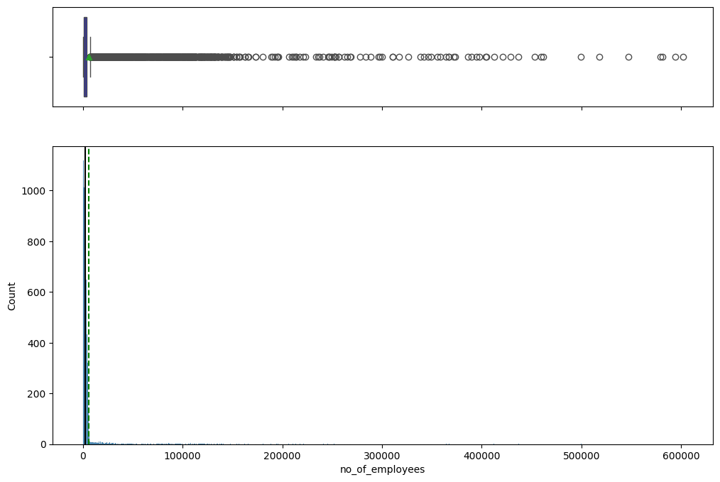

```python
# Print boxplot and histogram, and exclude fliers from boxplot
print_histogram_boxplot(df_eda, 'no_of_employees', showfliers=False)
```

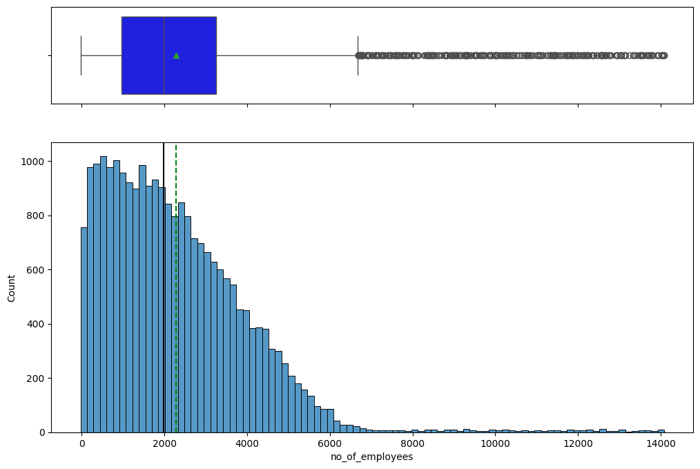

```python
# Since a large number of values appear on the right side, let's exclude the outliers and redraw by excluding the rightmost 5% of the data
capped_df_no_of_employees = cap_values_by_percent(df_eda, 'no_of_employees', .00, .95)

print_histogram_boxplot(capped_df_no_of_employees, 'no_of_employees')
```

```python
negative_emp_count = df_eda[df_eda['no_of_employees'] <= 0].shape[0]
print('There are',negative_emp_count, 'rows with negative employee counts')
```

```
There are 33 rows with negative employee counts
```

**OBSERVATIONS**

For no_of_employees:

- Mean = 5667.043210361067
- Median = 2109.0
- Range = -26 to 602069 ( 602095 )
- Distribution is skewed to the right
- A very wide range of values exist, including 33 negative values. Later, we should ensure we have only positive values, or find out if this is due to attrition over some period of time.
- The average number of employees is 5667, but 50% of the dataset has an employee count of 2109.
  - Mean and median are extremely different.
  - Even after removing 5% of the rightmost outliers, we can still observe right skewness.

##### yr_of_estab

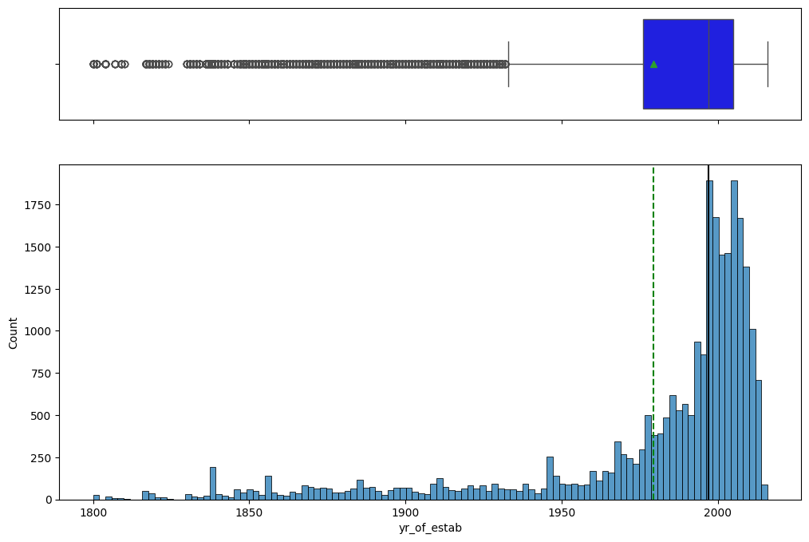

```python
print_histogram_boxplot(df_eda, 'yr_of_estab')
```

**OBSERVATIONS**

For yr_of_estab :

- Mean = 1979.409929356358
- Median = 1997.0
- Range = 1800 to 2016 ( 216 )
- Distribution is skewed to the left.
- Mean and median are not extremely different, although we can still observe some left skewness in the data. Some companies have been in existence for a very long time, while others have been around since 1800.
- We can see distinct multi-modal peaks during the early 2000s, likely aligning with the advent of the Internet and dot-com explosion of new companies.
- The number of companies established in more recent years is much lower.

##### prevailing_wage

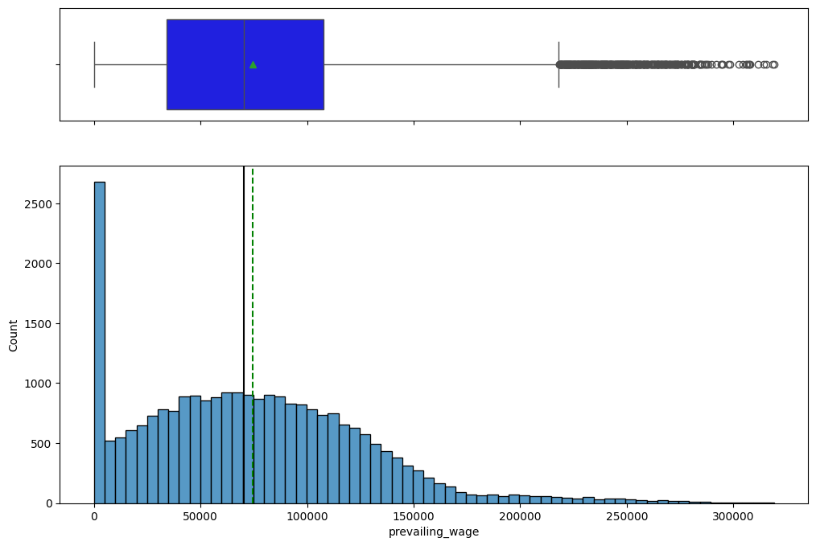

```python
print_histogram_boxplot(df_eda, 'prevailing_wage')
```

```python
df_eda.groupby('unit_of_wage')['prevailing_wage'].mean()
```

| unit_of_wage | prevailing_wage |
| --- | --- |
| Hour | 414.570513 |
| Month | 87592.864045 |
| Week | 85606.820515 |
| Year | 81228.077133 |

**dtype:** float64

**OBSERVATIONS**

For prevailing_wage :

- Mean = 74455.81459209183
- Median = 70308.20999999999
- Range = 2.1367 to 319210.27 ( 319208.133 )
- Distribution is skewed to the right.

Based on unit_of_wage, the average prevailing wages are as follows

- Hour: 414.57
- Month: 87,593
- Week: 85,607
- Year: 81,228

The averages for monthly, weekly, and annually seem suspect, since they are all very close in value. We need to investigate this further later.

#### Categorical values

##### case_id

Since this is an identifier column, we don't need to examine it from a univariate perspective.

##### continent

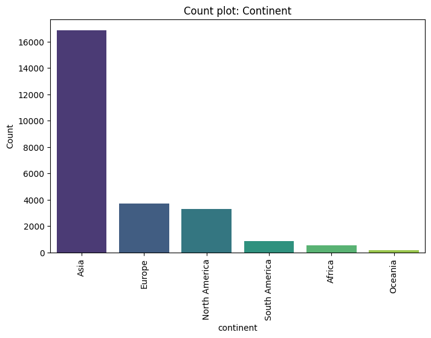

```python
# Print count plot
print_simple_count_barplot(df_eda, 'continent', 8, 5, 'Count plot: Continent')
```

```python
# Print value counts and percentages

value_counts, value_percentages = get_value_counts(df_eda, 'continent')

print('***** Continent *****')
print(value_counts)
print(value_percentages)
```

```
***** Continent *****
continent
Asia             16861
Europe            3732
North America     3292
South America      852
Africa             551
Oceania            192
Name: count, dtype: int64
continent
Asia             0.661735
Europe           0.146468
North America    0.129199
South America    0.033438
Africa           0.021625
Oceania          0.007535
Name: proportion, dtype: float64
```

##### education_of_employee

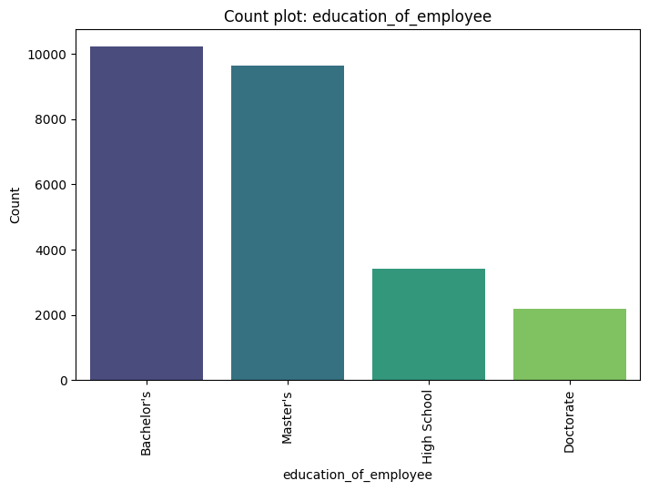

```python
# Print count plot
print_simple_count_barplot(df_eda, 'education_of_employee', 8, 5, 'Count plot: education_of_employee')
```

```python
# Print value counts and percentages

value_counts, value_percentages = get_value_counts(df_eda, 'education_of_employee')

print('***** Education *****')
print(value_counts,'\n')
print(value_percentages)
```

```
***** Education *****
education_of_employee
Bachelor's     10234
Master's        9634
High School     3420
Doctorate       2192
Name: count, dtype: int64

education_of_employee
Bachelor's     0.401648
Master's       0.378100
High School    0.134223
Doctorate      0.086028
Name: proportion, dtype: float64
```

##### has_job_experience

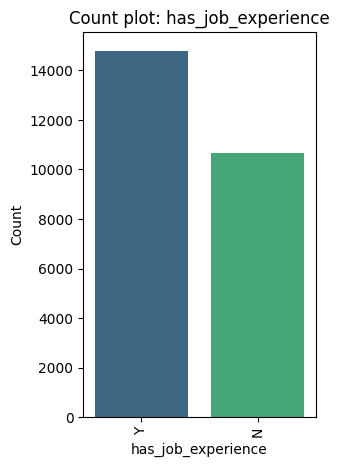

```python
# Print count plot
print_simple_count_barplot(df_eda, 'has_job_experience', 3, 5, 'Count plot: has_job_experience')
```

```python
# Print value counts and percentages

value_counts, value_percentages = get_value_counts(df_eda, 'has_job_experience')

print('***** Job Experience *****')
print(value_counts,'\n')
print(value_percentages)
```

```
***** Job Experience *****
has_job_experience
Y    14802
N    10678
Name: count, dtype: int64

has_job_experience
Y    0.580926
N    0.419074
Name: proportion, dtype: float64
```

##### requires_job_training

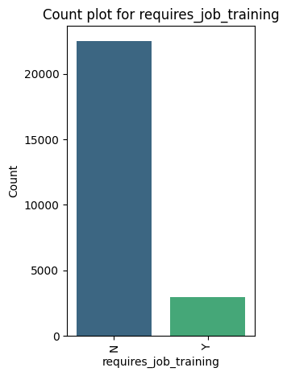

```python
print_simple_count_barplot(df_eda, 'requires_job_training', 3, 5, 'Count plot for requires_job_training')
```

```python
# Print value counts and percentages

value_counts, value_percentages = get_value_counts(df_eda, 'requires_job_training')

print('***** Job Training *****')
print(value_counts,'\n')
print(value_percentages)
```

```
***** Job Training *****
requires_job_training
N    22525
Y     2955
Name: count, dtype: int64

requires_job_training
N    0.884027
Y    0.115973
Name: proportion, dtype: float64
```

##### region_of_employment

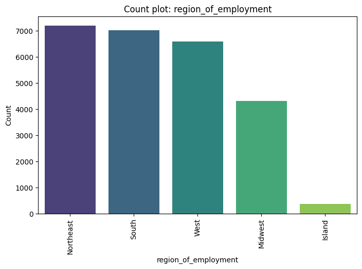

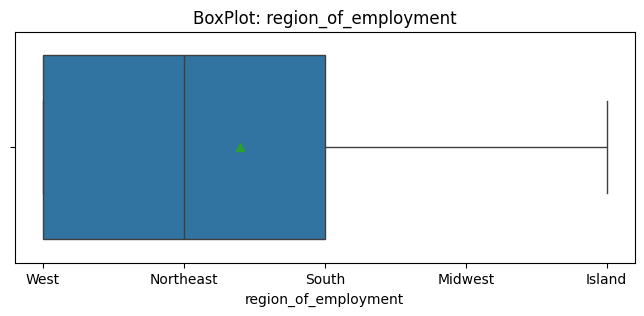

```python
# Print count plot
print_simple_count_barplot(df_eda, 'region_of_employment', 8, 5, 'Count plot: region_of_employment')

# Print Boxplot
print_boxplot(df_eda, 'region_of_employment', 8, 3, 'BoxPlot: region_of_employment')
```

```python
# Print value counts and percentages

value_counts, value_percentages = get_value_counts(df_eda, 'region_of_employment')

print('***** Region *****')
print(value_counts,'\n')
print(value_percentages)
```

```
***** Region *****
region_of_employment
Northeast    7195
South        7017
West         6586
Midwest      4307
Island        375
Name: count, dtype: int64

region_of_employment
Northeast    0.282378
South        0.275392
West         0.258477
Midwest      0.169035
Island       0.014717
Name: proportion, dtype: float64
```

##### unit_of_wage

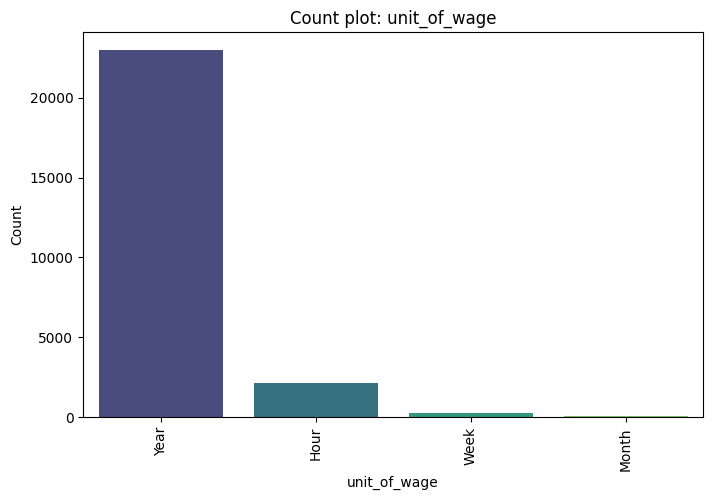

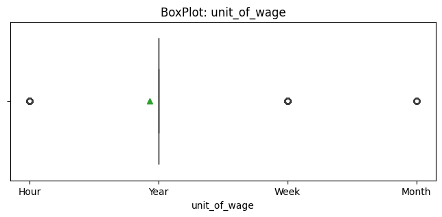

```python
# Print count plot
print_simple_count_barplot(df_eda, 'unit_of_wage', 8, 5, 'Count plot: unit_of_wage')

# Print Boxplot
print_boxplot(df_eda, 'unit_of_wage', 8, 3, 'BoxPlot: unit_of_wage')
```

```python
# Print value counts and percentages

value_counts, value_percentages = get_value_counts(df_eda, 'unit_of_wage')

print('***** Unit of Wage *****')
print(value_counts,'\n')
print(value_percentages)
```

```
***** Unit of Wage *****
unit_of_wage
Year     22962
Hour      2157
Week       272
Month       89
Name: count, dtype: int64

unit_of_wage
Year     0.901177
Hour     0.084655
Week     0.010675
Month    0.003493
Name: proportion, dtype: float64
```

##### full_time_position

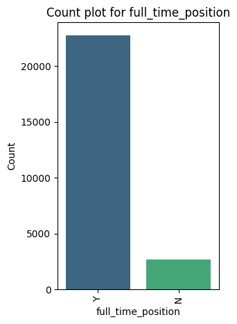

```python
# Print count plot
print_simple_count_barplot(df_eda, 'full_time_position', 3, 5, 'Count plot for full_time_position')
```

```python
# Print value counts and percentages

value_counts, value_percentages = get_value_counts(df_eda, 'full_time_position')

print('***** Full Time Position *****')
print(value_counts,'\n')
print(value_percentages)
```

```
***** Full Time Position *****
full_time_position
Y    22773
N     2707
Name: count, dtype: int64

full_time_position
Y    0.89376
N    0.10624
Name: proportion, dtype: float64
```

##### case_status

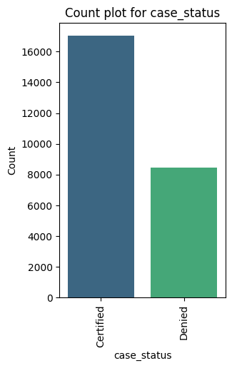

```python
# Print count plot
print_simple_count_barplot(df_eda, 'case_status', 3, 5, 'Count plot for case_status')
```

```python
# Print value counts and percentages

value_counts, value_percentages = get_value_counts(df_eda, 'case_status')

print('***** Case Status *****')
print(value_counts,'\n')
print(value_percentages)
```

```
***** Case Status *****
case_status
Certified    17018
Denied        8462
Name: count, dtype: int64

case_status
Certified    0.667896
Denied       0.332104
Name: proportion, dtype: float64
```

**OBSERVATIONS**

Continent

- Most applicants are located in Asia (16861, or 66%)
- Europe (15%) and North America (13%) have about the same number of applicants, but still only about 1/4 of the number present in Asia.

Education

- Most applicants (about 20K in our set) have some degree of higher education.
  - 38% have Master's degrees
  - 40% have Bachelor's degrees
  - 13% have a high school education
  - 9% have Doctorate degrees
- The dataset does not include any applicants with less than a high school education

Job Experience

- Slightly more applicants (14K, or 58%) have job experience than not (10K, or 42%), although the numbers are fairly evenly split.

Requires Job Training

- Most applicants (22.5K, or 88%) do not require job training.

Region of Employment

- Northeast, South and West are the most commonly desired employment regions.
- Midwest has fewer applications, but more than Island regions.
  - Northeast: 28%
  - South: 28%
  - West: 26%
  - Midwest: 17%
  - Island: 1%

Unit of Wage

- Most applications (over 90%) are geared toward positions with a yearly income.
- Very few applications exist for hourly, monthly or weekly wages (less than 10%).

Full Time Position

- Most applicants (almost 90%) desire full-time positions, while very few (less than 10%) are seeking other work arrangements.

Case Status

- One-third of the current applications were denied, while two thirds were certified.

## Bivariate Analysis

As part of our bivariate analysis, we will look for variable correlations, and will want to focus our efforts otherwise on the central feature of the analysis:

- case_status: whether the applicant was certified or not

Earlier, we added some integer representations for this series, as well as a few others, to aid us in our analysis.

### Variable Correlation

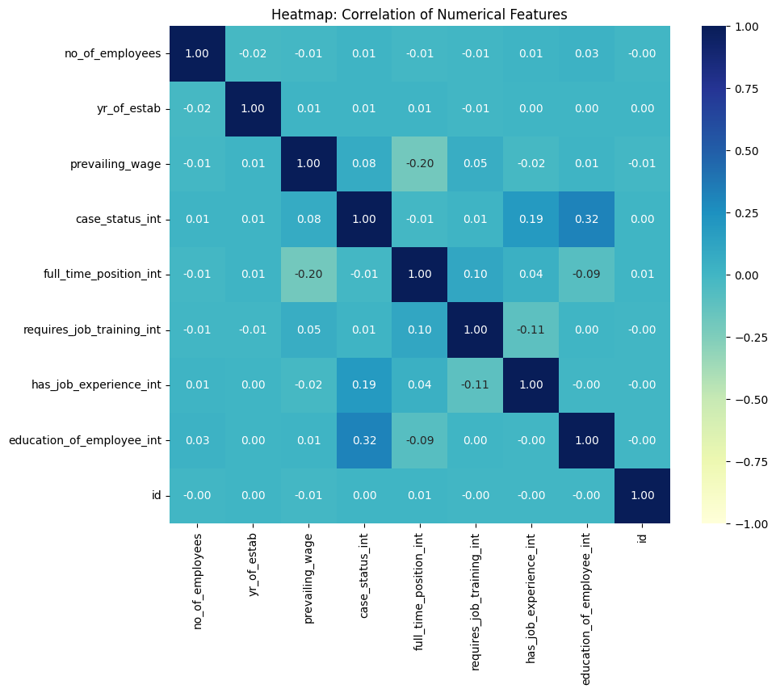

```python
# Plot the variable correlations for our numerical variables

# Create a numerical column list for EDA only
list_numcol_eda = df_eda.select_dtypes(np.number)

# Set figure size and title
plt.figure(figsize=(10, 8))
plt.title('Heatmap: Correlation of Numerical Features')

# Create a heat map
sns.heatmap(list_numcol_eda.corr(), annot=True, vmin=-1, vmax=1, fmt='.2f', cmap='YlGnBu')

# Show the plot
plt.show()
```

**OBSERVATIONS**

Next, let's look at the relationships between these pairs of variables.

### case_status vs. job_experience

Does job experience contribute to case status certifications?

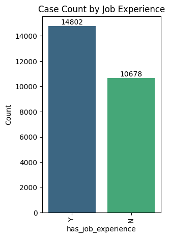

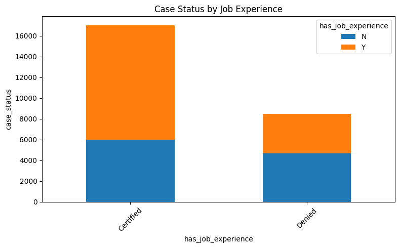

```python
# Plot case status against job experience
df_case_status_jobexp = df_eda.groupby('has_job_experience')['case_status'].count().reset_index()
print_simple_labeled_count_barplot(df_case_status_jobexp, 'has_job_experience', 3, 5, 'Case Count by Job Experience')

# Print simple stacked barplot for case status against job experience
print_stacked_barplot(df_eda, 'case_status', 'has_job_experience', 8, 5, 'Case Status by Job Experience')
```

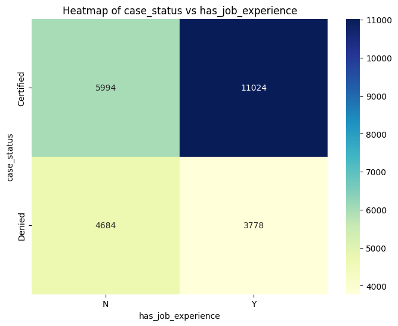

```python
# Print simple heatmap for  case_status vs. job_experience
plot_heatmap(df_eda, 'has_job_experience', 'case_status')
```

```python
# Create pivot table
pivot_case_status_jobexp = df_eda.pivot_table(
    index=['case_status','has_job_experience'],
    values=['has_job_experience_int'],
    aggfunc='count',
    margins=True,
    margins_name='Total'
)

print('Case count by status')
display(pivot_case_status_jobexp)


# Retrieve the total count
total_count = pivot_case_status_jobexp.loc['Total']

# Retrieve specific counts
approved_yes_count = pivot_case_status_jobexp.loc[('Certified', 'Y')]
approved_no_count = pivot_case_status_jobexp.loc[('Certified', 'N')]
denied_yes_count = pivot_case_status_jobexp.loc[('Denied', 'Y')]
denied_no_count = pivot_case_status_jobexp.loc[('Denied', 'N')]

# Calculate the percentage
percentage_approved_yes = (approved_yes_count / total_count) * 100
percentage_approved_no = (approved_no_count / total_count) * 100
percentage_denied_yes = (denied_yes_count / total_count) * 100
percentage_denied_no = (denied_no_count / total_count) * 100

print(f'\nPercentage of Approved cases with job experience: {percentage_approved_yes}%')
print(f'\nPercentage of Approved cases with no job experience: {percentage_approved_no}%')
print(f'\nPercentage of Denied cases with job experience: {percentage_denied_yes}%')
print(f'\nPercentage of Denied cases with no job experience: {percentage_denied_no}%')
```

```
Case count by status
```

| case_status | has_job_experience | has_job_experience_int |
| --- | --- | --- |
| Certified | N | 5994 |
|  | Y | 11024 |
| Denied | N | 4684 |
|  | Y | 3778 |
| Total |  | 25480 |

```
Percentage of Approved cases with job experience:                     has_job_experience_int
has_job_experience
                                 43.265306%

Percentage of Approved cases with no job experience:                     has_job_experience_int
has_job_experience
                                 23.524333%

Percentage of Denied cases with job experience:                     has_job_experience_int
has_job_experience
                                 14.827316%

Percentage of Denied cases with no job experience:                     has_job_experience_int
has_job_experience
                                 18.383046%
```

### case_status vs. education_of_employee

Does level of education contribute to case status certification?

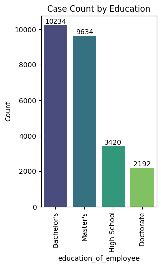

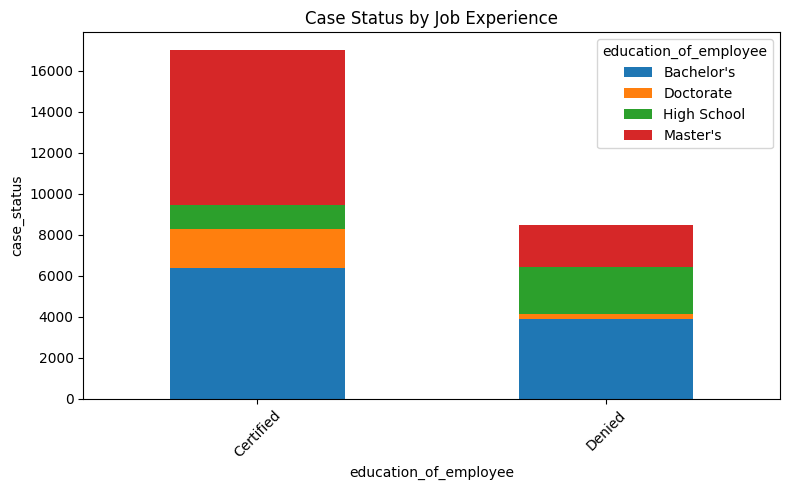

```python
# Plot case status against education
df_case_status_education = df_eda.groupby('education_of_employee')['case_status'].count().reset_index()
print_simple_labeled_count_barplot(df_case_status_education, 'education_of_employee', 3, 5, 'Case Count by Education')

# Print simple stacked barplot for case status against job experience
print_stacked_barplot(df_eda, 'case_status', 'education_of_employee', 8, 5, 'Case Status by Job Experience')
```

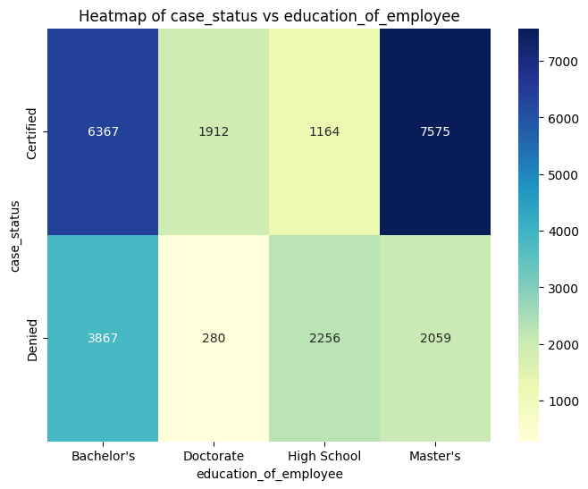

```python
# Print simple heatmap for case_status vs. education_of_employee
plot_heatmap(df_eda, 'education_of_employee', 'case_status')
```

```python
# Create grouping to get counts
df_eda_group_education = df_eda.groupby(['case_status','education_of_employee']).size().reset_index(name='count')
df_eda_group_education.value_counts()
```

| case_status | education_of_employee | count | count |
| --- | --- | --- | --- |
| Certified | Bachelor's | 6367 | 1 |
|  | Doctorate | 1912 | 1 |
|  | High School | 1164 | 1 |
|  | Master's | 7575 | 1 |
| Denied | Bachelor's | 3867 | 1 |
|  | Doctorate | 280 | 1 |
|  | High School | 2256 | 1 |
|  | Master's | 2059 | 1 |

**dtype:** int64

### case_status vs. continent

Does case status result depend on location of applicant?

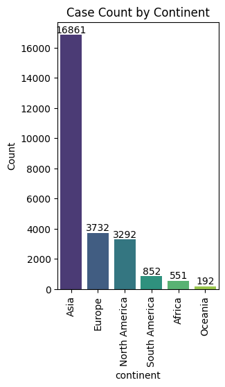

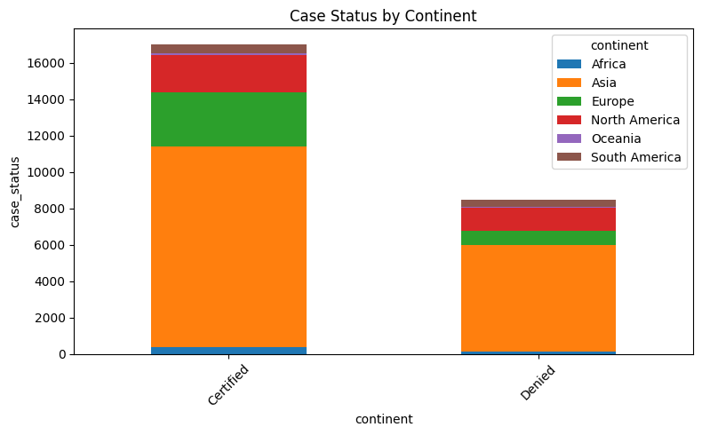

```python
# Plot case status against continent
df_case_status_education = df_eda.groupby('continent')['case_status'].count().reset_index()
print_simple_labeled_count_barplot(df_case_status_education, 'continent', 3, 5, 'Case Count by Continent')

# Print simple stacked barplot for case status against continent
print_stacked_barplot(df_eda, 'case_status', 'continent', 8, 5, 'Case Status by Continent')
```

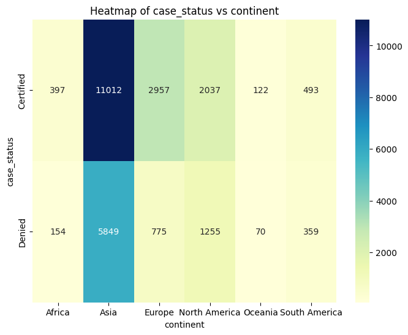

```python
# Print simple heatmap for case_status vs. continent
plot_heatmap(df_eda, 'continent', 'case_status')
```

```python
# Create grouping to get counts
df_eda_group_continent = df_eda.groupby(['case_status','continent']).size().reset_index(name='count')
df_eda_group_continent.value_counts()
```

| case_status | continent | count | count |
| --- | --- | --- | --- |
| Certified | Africa | 397 | 1 |
|  | Asia | 11012 | 1 |
|  | Europe | 2957 | 1 |
|  | North America | 2037 | 1 |
|  | Oceania | 122 | 1 |
|  | South America | 493 | 1 |
| Denied | Africa | 154 | 1 |
|  | Asia | 5849 | 1 |
|  | Europe | 775 | 1 |
|  | North America | 1255 | 1 |
|  | Oceania | 70 | 1 |
|  | South America | 359 | 1 |

**dtype:** int64

### case_status vs. prevailing_wage

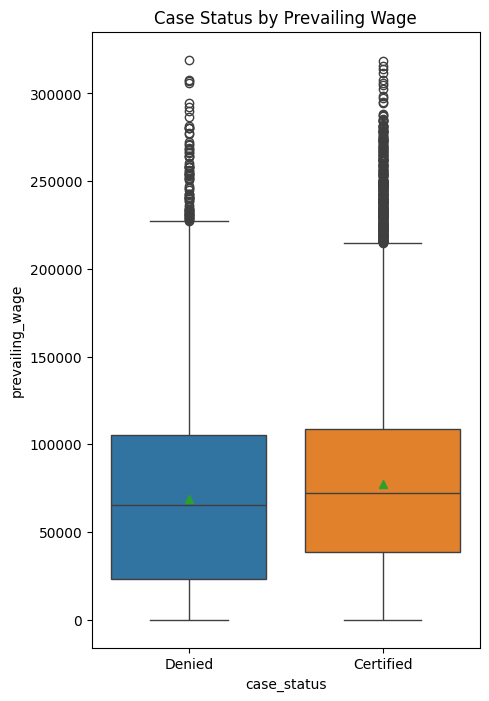

```python
# Print Boxplot for case status vs. wages
print_categorical_boxplot(df_eda, 'case_status', 'prevailing_wage', 5, 8, 'Case Status by Prevailing Wage')
```

```python
# Get mean for each category
print('Wage mean for Certified applications:',df_eda[df_eda['case_status_int'] == 1]['prevailing_wage'].mean())
print('Wage mean for Denied applications:',df_eda[df_eda['case_status_int'] == 0]['prevailing_wage'].mean())
```

```
Wage mean for Certified applications: 77293.6192431308
Wage mean for Denied applications: 68748.68157963839
```

### prevailing_wage vs. full_time_position

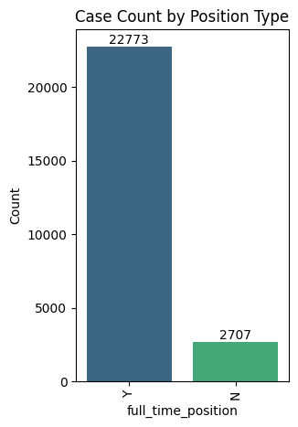

```python
# Plot case counts by full_time_position
df_wage_postype = df_eda.groupby('full_time_position')['case_id'].count().reset_index()
print_simple_labeled_count_barplot(df_wage_postype, 'full_time_position', 3, 5, 'Case Count by Position Type')
```

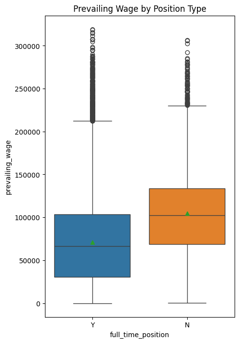

```python
# Print Boxplot for position type vs. wages
print_categorical_boxplot(df_eda, 'full_time_position', 'prevailing_wage', 5, 8, 'Prevailing Wage by Position Type')
```

```python
# Get mean for each category
print('Wage mean for full time positions:',df_eda[df_eda['full_time_position_int'] == 1]['prevailing_wage'].mean())
print('Wage mean for non-full time positions:',df_eda[df_eda['full_time_position_int'] == 0]['prevailing_wage'].mean())
```

```
Wage mean for full time positions: 70855.32651052123
Wage mean for non-full time positions: 104745.40272715183
```

### prevailing_wage vs. requires_job_training

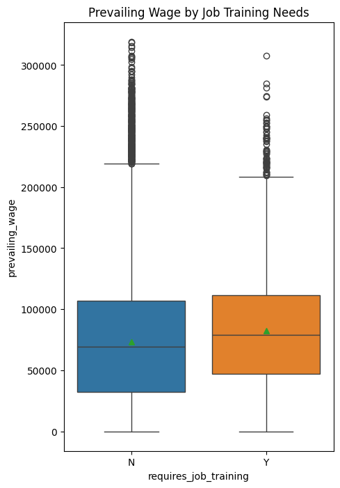

```python
# Print Boxplot for position type vs. wages
print_categorical_boxplot(df_eda, 'requires_job_training', 'prevailing_wage', 5, 8, 'Prevailing Wage by Job Training Needs')
```

```python
# Get mean for each category
print('Wage mean for applications requiring training:',df_eda[df_eda['requires_job_training_int'] == 1]['prevailing_wage'].mean())
print('Wage mean for applications not requiring training:',df_eda[df_eda['requires_job_training_int'] == 0]['prevailing_wage'].mean())
```

```
Wage mean for applications requiring training: 82467.72026994925
Wage mean for applications not requiring training: 73404.75216021309
```

### job_experience vs. requires_job_training

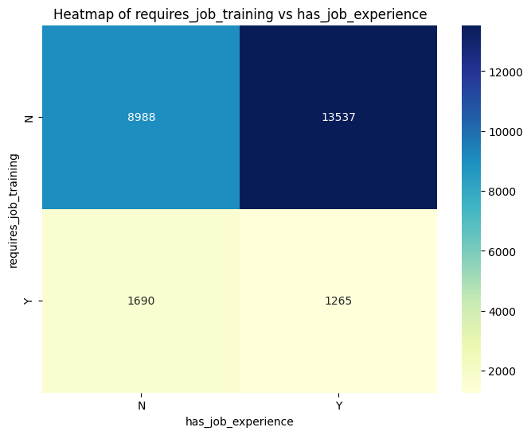

```python
# Print simple heatmap for job experience against needs training
plot_heatmap(df_eda, 'has_job_experience', 'requires_job_training')
```

```python
# Create grouping to get counts
df_eda_group_education = df_eda.groupby(['requires_job_training','has_job_experience']).size().reset_index(name='count')
df_eda_group_education.value_counts()
```

| requires_job_training | has_job_experience | count | count |
| --- | --- | --- | --- |
| N | N | 8988 | 1 |
|  | Y | 13537 | 1 |
| Y | N | 1690 | 1 |
|  | Y | 1265 | 1 |

**dtype:** int64

### full_time_position vs. requires_job_training

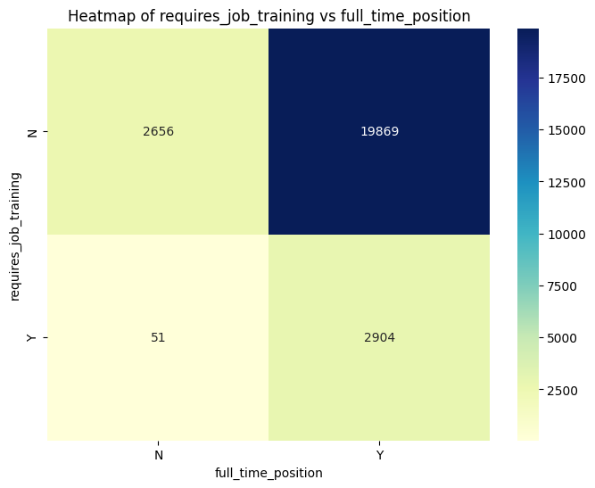

```python
# Print heatmap for full time position against needs training
plot_heatmap(df_eda, 'full_time_position', 'requires_job_training')
```

### full_time_position vs. job_experience

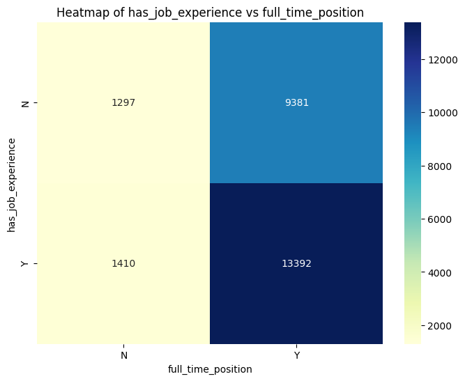

```python
# Print heatmap for full time position against job experience
plot_heatmap(df_eda, 'full_time_position', 'has_job_experience')
```

**OBSERVATIONS: BIVARIATE ANALYSIS**

With regard to case_status, it appears that level of education, job experience and prevailing wages are all important features when it comes to certifying visa applications. We will investigate this later during our model construction.

Job Experience:

Education:

Prevailing Wage:

- The range of prevailing wages is similar for both Certified and Denied applications
- Average prevailing wages for Certified applicants is 77,293.
- Average prevailing wages for Denied applicants is slightly lower, at 68,748.
- Even though the range of wages is similar for both full time and non-full time, the average prevailling wages differ.
  - Average prevailing wages for full time positions: 70,855
  - Average prevailing wages for non-full time positions 104,745
    - Similarly, we see that wages for applicants requiring training is slightly higher than for applications not requiring job training.
  - Average prevailing wages for applications requiring training: 82,467
  - Average prevailing wages for applications not requiring training: 73,404

Job Training:

- Most applicants do not require job training
  - 43% of Certified applicants have job experience
  - 24% of Certified applicants lack experience
  - 15% of Denied applications have job experience
  - 18% of Denied applications lack job experience

# Questions to Answer

Through our EDA and analysis, we will answer these key questions:

- Does education play a role in Visa certification?
- How does the visa status vary across different continents?
- Does work experience influence visa status?
- Which pay unit is most likely to be certified for a visa?
- How does the visa status change with the prevailing wage?

##### **Question 1: Does education play a role in Visa certification?**

Those with higher education may want to travel abroad for a well-paid job.

**Answer**

Yes, level of education does impact whether or not an application is Certified or Denied. Over half of our Certified applicants have a Master's or Bachelor's degree.

Doctoral degrees greatly increase the odds of being Certified, and only about 1 in 7 applications are Denied (only about 1%).

Comparing by education level, high school only educated applicants are denied 66% of the time. By contrast, all other education levels have a much higher ratio of Certified to Denied results.

```
Counts by Education Level:
                           Certified  Denied
Bachelor's                  6367    3867
Doctorate                   1912     280
High School                 1164    2256
Master's                    7575    2059

As Percentage of Case Status by Education Level:
                       Certified     Denied
Bachelor's             62.214188  37.785812
Doctorate              87.226277  12.773723
High School            34.035088  65.964912
Master's               78.627777  21.372223

As overall percentage contribution by Education Level:
                       Certified     Denied
Bachelor's             24.988226  15.176609
Doctorate               7.503925   1.098901
High School             4.568289   8.854003
Master's               29.729199   8.080848
```

Supporting Calculations

```python
# Create a crosstab
crosstab_education_case_status = pd.crosstab(df['education_of_employee'], df['case_status'])

# Calculate the percentage for each status by continent
crosstab_education_case_status_percentage = crosstab_education_case_status.div(crosstab_education_case_status.sum(axis=1), axis=0) * 100

# Calculate overall percentage contribution by category
crosstab_overall_percentage_education = crosstab_education_case_status / crosstab_education_case_status.values.sum() * 100

# Display the crosstab
print("Crosstab of case_status by Education")
print(crosstab_education_case_status)

print("\nPercentage of Case Status by Education")
print(crosstab_education_case_status_percentage)

# Display the overall percentage contribution
print("\nOverall percentage contribution by category")
print(crosstab_overall_percentage_education)
```

```
Crosstab of case_status by Education
case_status            Certified  Denied
education_of_employee
Bachelor's                  6367    3867
Doctorate                   1912     280
High School                 1164    2256
Master's                    7575    2059

Percentage of Case Status by Education
case_status            Certified     Denied
education_of_employee
Bachelor's             62.214188  37.785812
Doctorate              87.226277  12.773723
High School            34.035088  65.964912
Master's               78.627777  21.372223

Overall percentage contribution by category
case_status            Certified     Denied
education_of_employee
Bachelor's             24.988226  15.176609
Doctorate               7.503925   1.098901
High School             4.568289   8.854003
Master's               29.729199   8.080848
```

##### **Question 2: How does the visa status vary across different continents?**

**Answer**

Looking at each continent, we can observe that the majority of applications are Certified for each continent.

- South America has the worst ratio (42% denied, 58% Certified)
- Europe has the best ratio (21% Denied, 79% approved).
- Africa-based applications are nearly as successful (28% Denied, 72% approved).

Below is the breakdown by continent and % contribution both at the continental and overall level.

```
Crosstab of case_status by Continent
              Certified  Denied
Africa               397     154
Asia               11012    5849
Europe              2957     775
North America       2037    1255
Oceania              122      70
South America        493     359

Percentage of Case Status by Continent:
              Certified     Denied
Africa         72.050817  27.949183
Asia           65.310480  34.689520
Europe         79.233655  20.766345
North America  61.877278  38.122722
Oceania        63.541667  36.458333
South America  57.863850  42.136150

Overall percentage contribution by category:
              Certified     Denied
Africa          1.558085   0.604396
Asia           43.218210  22.955259
Europe         11.605181   3.041601
North America   7.994505   4.925432
Oceania         0.478807   0.274725
South America   1.934851   1.408948
```

Supporting Calculations

```python
# Create a crosstab
crosstab_continent_case_status = pd.crosstab(df['continent'], df['case_status'])

# Calculate the percentage for each status by continent
crosstab_continent_case_status_percentage = crosstab_continent_case_status.div(crosstab_continent_case_status.sum(axis=1), axis=0) * 100

# Calculate overall percentage contribution by category
crosstab_overall_percentage_continent = crosstab_continent_case_status / crosstab_continent_case_status.values.sum() * 100

# Display the crosstab
print("Crosstab of case_status by Continent")
print(crosstab_continent_case_status)

print("\nPercentage of Case Status by Continent")
print(crosstab_continent_case_status_percentage)

# Display the overall percentage contribution
print("\nOverall percentage contribution by category")
print(crosstab_overall_percentage_continent)
```

```
Crosstab of case_status by Continent
case_status    Certified  Denied
continent
Africa               397     154
Asia               11012    5849
Europe              2957     775
North America       2037    1255
Oceania              122      70
South America        493     359

Percentage of Case Status by Continent
case_status    Certified     Denied
continent
Africa         72.050817  27.949183
Asia           65.310480  34.689520
Europe         79.233655  20.766345
North America  61.877278  38.122722
Oceania        63.541667  36.458333
South America  57.863850  42.136150

Overall percentage contribution by category
case_status    Certified     Denied
continent
Africa          1.558085   0.604396
Asia           43.218210  22.955259
Europe         11.605181   3.041601
North America   7.994505   4.925432
Oceania         0.478807   0.274725
South America   1.934851   1.408948
```